# Planejamento e e Análise de experimentos II -atividade I

[figure not shown]

joseferson da silva barreto

20/12/2021

## Objeivo

Realizar um Delineamento em Delineamento Completamente Casualizado (DIC) afim de solucionar a questão a baixo

## Questão proposta

Considerando os dados de um experimento inteiramente casualisado, com 4 repetiçõoes no esquema fatorial, para testar os efeitos de 3 Recipientes $(R_1, R_2 e R_3)$ e 2 Espécies de eucaliptos $(E_1 e E_2)$, para a produção de mudas. Quanto ao desenvolvimento das mudas os Recipientes e as Espécies testados foram:

**$R_1=$** saco plástico pequeno;

**$R_2=$** saco plástico grande;

**$R_3=$** laminado;

**$E_1=$** Eucalyptus citriodora;

**$E_2=$** Eucalyptus grandis.

As alturas médias das mudas em cm, aos 80 dias de idade são apresentados na Tabela abaixo:

|  | Tratamentos | repetição1 | repetição2 | repetição3 | repetição4 | Totais |
| --- | --- | --- | --- | --- | --- | --- |
| 1 | 1-R1E1 | 26.2 | 26 | 25 | 25.4 | 102.6 |
| 2 | 2-R1E2 | 24.8 | 24.6 | 26.7 | 25.2 | 101.3 |
| 3 | 3-R2E1 | 25.7 | 26.3 | 25.1 | 26.4 | 103.5 |
| 4 | 4-R2E2 | 19.6 | 21.1 | 19 | 18.6 | 78.3 |
| 5 | 5-R3E1 | 22.8 | 19.4 | 18.8 | 19.2 | 80.2 |
| 6 | 6-R3E2 | 19.8 | 21.4 | 22.8 | 21.3 | 85.3 |
| 7 | Total | 138.9 | 138.8 | 137.4 | 136.1 | 551.2 |

## DIC em esquema fatorial

Vamos montar o delineamento em Delineamento Completamente Casualizado , definindo algumas varáveis como :

**B:** receberá o número das espécies de elcalyptos

**A:** receberá o número das espécies de recepientes **t:** receberá o número de tratamentos

**n:** será o número de parcelas em nosso experimento

**Unidade:** receberá o número de parcelas do experimento

**Trat:** receberá o número das espécies de recepientes igual receberá o número das espécies de elcalyptos

```r
require(dae)


n<- 24     # n = n?mero de parcelas
unidade<- list(parcela=n); # unidade # lista (numera) 1 vetor de parcelas de tamanho n
i<- 3 # n?mero de n?veis do fator A
j<- 2 # n?mero de n?veis do fator B
r<- 4 # n?mero de repeti??es

A <- factor(rep(c(1:i), each=r, times=j), labels=c("R1","R2","R3"))
B <- factor(rep(c(1:j), each=r*i), labels=c("E1","E2"))
trat<- A:B
```

## Análise dos dados

**Y=** recebe todas as parcelas do experimento ;

**n=** Recebe o número total de parcelas do experimento;

**i=** Recebe número de níveis do fator A: recipentes;

**j=** Recebe número de níveis do fator B: elcaliptos;

**r=** número de repetições;

**rec=** Recebe os níveis fator recepiente ;

**elcalipos=** Recebe os níveis do fator espévies de elcalyptos ;

**trat=** Recebe os níveis dos tratamentos ;

**parcelas=** recebe o números de parcelas indo de 1 a n(**24**) ;

**DIC=** Recebe nosso DataFrame formado pela junção das variáveis : (**parcelas,elcalipos,rec ,trat,y**).

```r
y<- c(26.2, 26, 25, 25.4,
24.8,   24.6,   26.7,   25.2,
25.7,   26.3,   25.1,   26.4,
19.6,   21.1,   19, 18.6,
22.8,   19.4,   18.8,   19.2,
19.8,   21.4,   22.8,   21.3
)



n<- length(y);# n
i<- 3# n?mero de n?veis do fator A: recipentes
j<- 2 # n?mero de n?veis do fator B: elcaliptos
r<- 4 # n?mero de repeti??es

parcelas<- factor(c(1:n));
rec <- factor(rep(c(1:i), each=r, times=j), labels=c("R1","R2","R3"))
elcalipos<- factor(rep(c(1:j), each=r*i), labels=c("E1","E2"));
trat<- factor(rep(c("T1","T2","T3","T4","T5","T6"),each=4));

DIC<- data.frame(parcelas,elcalipos,rec ,trat,y);
```

|  | parcelas | elcalipos | rec | trat | y |
| --- | --- | --- | --- | --- | --- |
| 1 | 1 | E1 | R1 | T1 | 26.2 |
| 2 | 2 | E1 | R1 | T1 | 26 |
| 3 | 3 | E1 | R1 | T1 | 25 |
| 4 | 4 | E1 | R1 | T1 | 25.4 |
| 5 | 5 | E1 | R2 | T2 | 24.8 |
| 6 | 6 | E1 | R2 | T2 | 24.6 |
| 7 | 7 | E1 | R2 | T2 | 26.7 |
| 8 | 8 | E1 | R2 | T2 | 25.2 |
| 9 | 9 | E1 | R3 | T3 | 25.7 |
| 10 | 10 | E1 | R3 | T3 | 26.3 |

[output cut: 14 more lines]

## Análise descritiva

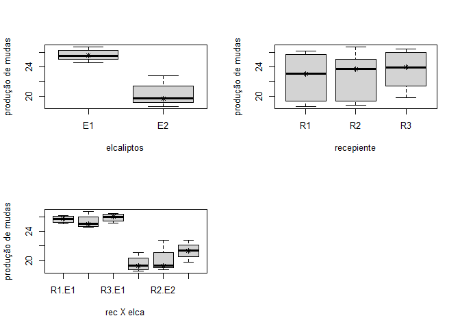

# gráficos de interação

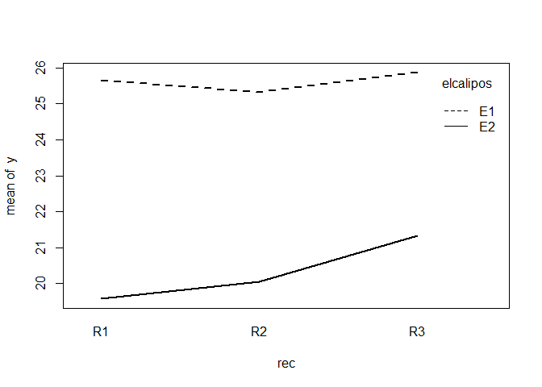

```r
#par(mfrow=c(1,2))
interaction.plot(rec,elcalipos,y, lwd=2)
```

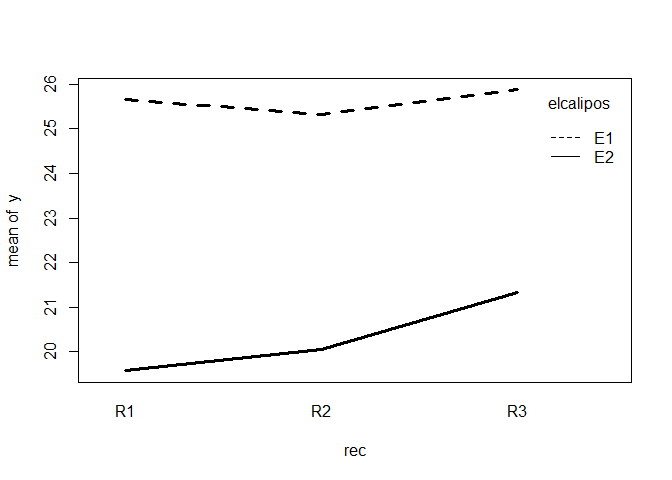

```r
interaction.plot(rec,elcalipos,y, lwd=3)
```

Nesse gráfico temos a média ,variancia e o desvio padrão

# média, variância e erro padronizado

```r
Var_A<-    tapply(y,rec,var)
Var_I<-    tapply(y,elcalipos,var)
Var_trat<- tapply(y,trat,var)

Media_A<-    tapply(y,rec,mean)
Media_I<-    tapply(y,elcalipos,mean)
Media_trat<- tapply(y,trat,mean)

Desvio_pad_A<- sqrt(Var_A)
Desvio_pad_I<- sqrt(Var_I)
Desvio_pad_trat<- sqrt(Var_trat)

V_A<- data.frame(Var_A, Media_A, Desvio_pad_A);
```

|  | Var_A | Media_A | Desvio_pad_A |
| --- | --- | --- | --- |
| R1 | 11.1898214285714 | 22.6125 | 3.34511904550069 |
| R2 | 9.80410714285714 | 22.6875 | 3.13115108911358 |
| R3 | 6.71428571428571 | 23.6 | 2.59119387817386 |

```r
V_I<- data.frame(Var_I, Media_I, Desvio_pad_I);
```

|  | Var_I | Media_I | Desvio_pad_I |
| --- | --- | --- | --- |
| E1 | 0.483333333333333 | 25.6166666666667 | 0.695221787153806 |
| E2 | 2.2669696969697 | 20.3166666666667 | 1.50564594010999 |

```r
V_trat<- data.frame(Var_trat, Media_trat, Desvio_pad_trat);
```

|  | Var_trat | Media_trat | Desvio_pad_trat |
| --- | --- | --- | --- |
| T1 | 0.303333333333333 | 25.65 | 0.55075705472861 |
| T2 | 0.902499999999999 | 25.325 | 0.949999999999999 |
| T3 | 0.362499999999999 | 25.875 | 0.602079728939614 |
| T4 | 1.2025 | 19.575 | 1.09658560997307 |
| T5 | 3.42333333333334 | 20.05 | 1.85022521151706 |
| T6 | 1.5025 | 21.325 | 1.22576506721313 |

# Teste de homogenidade fmax

## Hipóteses :

$H_0$:**as variâncias são homogêneas**

$H_1$:**as variâncias não são homogêneas**

Devemos ver o F na tabela do **F-máximo_tab(K,v)**: **k** estimativas de variâncias com **v** graus de liberdade cada uma (repetição ou blocos)

```r
F_cal = max(Var_trat)/min(Var_trat);


F_cal
```

```
## [1] 11.28571
```

Assim, $F_(cal_)<F_(tab_)$ não rejeita-se a hipótese $H_o$, logo as variâncias são homogeneas!.

### Gráficos para checar o diagnostico (suposições) :

### valores ajustados

**fit =** valores ajustados

**res =** resíduos ordinários

**res_padronizado =** resíduos padronizados

**res_student =** resíduo studentizado

```r
planta.lm <-   lm(y~ rec*elcalipos);planta.lm
```

```
##
## Call:
## lm(formula = y ~ rec * elcalipos)
##
## Coefficients:
##       (Intercept)              recR2              recR3        elcaliposE2
##            25.650             -0.325              0.225             -6.075
## recR2:elcaliposE2  recR3:elcaliposE2
##             0.800              1.525
```

```r
planta.aov<-  aov(y~ rec*elcalipos);planta.aov
```

```
## Call:
##    aov(formula = y ~ rec * elcalipos)
##
## Terms:
##                       rec elcalipos rec:elcalipos Residuals
## Sum of Squares    4.83583 168.54000       2.32750  23.09000
## Deg. of Freedom         2         1             2        18
##
## Residual standard error: 1.132598
## Estimated effects may be unbalanced
```

```r
planta_Error<-aov(y~ rec*elcalipos+ Error(parcelas))



fit            <- fitted(planta.lm)

res            <- residuals(planta.lm)


res_padronizado<- rstandard(planta.lm)


res_student    <- rstudent(planta.lm)
```

# Montando o data frame

```r
ajustados<-data.frame(parcelas, trat, y, res, res_padronizado, res_student, fit)
```

|  | parcelas | trat | y | res | res_padronizado | res_student | fit |
| --- | --- | --- | --- | --- | --- | --- | --- |
| 1 | 1 | T1 | 26.2 | 0.55 | 0.5607 | 0.5498 | 25.65 |
| 2 | 2 | T1 | 26 | 0.35 | 0.3568 | 0.348 | 25.65 |
| 3 | 3 | T1 | 25 | -0.65 | -0.6627 | -0.652 | 25.65 |
| 4 | 4 | T1 | 25.4 | -0.25 | -0.2549 | -0.2481 | 25.65 |
| 5 | 5 | T2 | 24.8 | -0.525 | -0.5352 | -0.5244 | 25.325 |
| 6 | 6 | T2 | 24.6 | -0.725 | -0.7391 | -0.7295 | 25.325 |
| 7 | 7 | T2 | 26.7 | 1.375 | 1.4018 | 1.4434 | 25.325 |
| 8 | 8 | T2 | 25.2 | -0.125 | -0.1274 | -0.1239 | 25.325 |
| 9 | 9 | T3 | 25.7 | -0.175 | -0.1784 | -0.1735 | 25.875 |
| 10 | 10 | T3 | 26.3 | 0.425 | 0.4333 | 0.4233 | 25.875 |

[output cut: 14 more lines]

### Verificando a homogenidade das variâncias

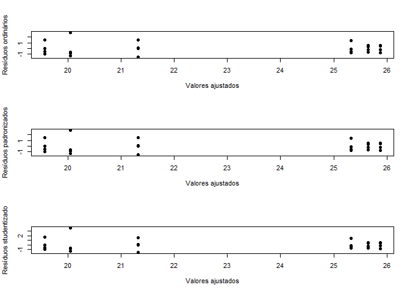

```r
par(mfrow=c(3,1))
plot(fit, res            , pch=16, xlab='Valores ajustados', ylab='Resíduos ordinários')
plot(fit, res_padronizado, pch=16, xlab='Valores ajustados', ylab='Resíduos padronizados')
plot(fit, res_student    , pch=16, xlab='Valores ajustados', ylab='Resíduos studentizado')
```

### Verifica a Homogeneidade de var entre trat e os fatores

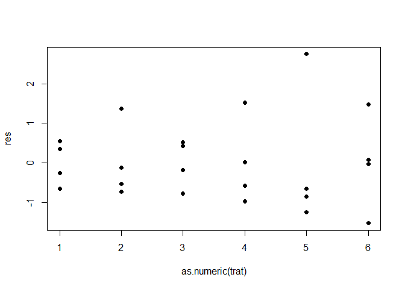

```r
plot(as.numeric(trat), res, pch = 16)
```

# Normalidados erros

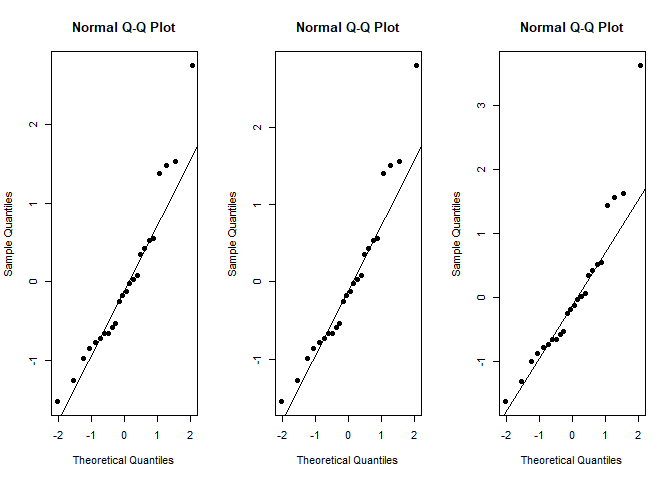

```r
#3) Normalidade dos erros : ok!

par(mfrow=c(1,3))
qqnorm(res, pch=16);                qqline(res)
qqnorm(res_padronizado, pch=16);    qqline(res_padronizado)
qqnorm(res_student, pch=16);        qqline(res_student)
```

Normal Q-Q) mostra que os pontos não fogem acentuadamente uma reta, indicando que a suposição de normalidade dos erros foi atendida.

# Teste de normalidade dos residuos ( Shapiro-Wilk )

Vamos começar analisando o resultado do teste de normalidade de resíduos(Shapiro-Wilk)

## hipóteses:

$H_0 :$ existe normalidade nos resíduos para $P \ge 0,05$

$H_1 :$ não existe normalidade dos resíduos $P < 0,05$

```r
shapiro.test(planta.lm$res)
```

```
##
##  Shapiro-Wilk normality test
##
## data:  planta.lm$res
## W = 0.9293, p-value = 0.09402
```

De acordo com o teste de Shapiro-Wilk a 5% de significancia,não rejeita-se a hipótese nula,logo, os residuos podem ser considerados normais.

### verificar se necessita de transformação

Vamos verificar se será necessário transformação , caso o número 1 pertencer ao intervalo, a variável resposta (y) não necessita de transforção.

```r
require(MASS)
```

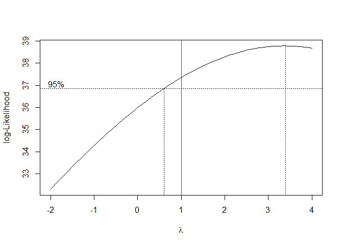

```r
boxcox(planta.lm, lam=seq(-2, 4, 1/10))
abline(v=1, col='red')
```

Como podemos ver o **1** está no intervalo ,logo, não será necessário transformação

# Independência das observações

### Dificil de ser verificada…gráfico de indice

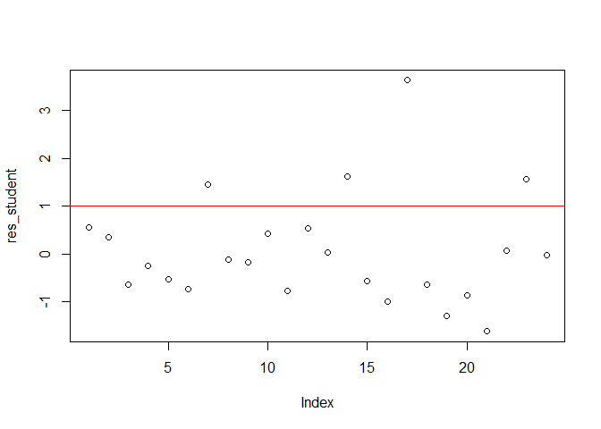

```
## integer(0)
```

```r
# 4) Independ?ncia das observações
# Dificil de ser verificada...gráfico de indice


plot(res_student)
abline(h=1,col="red")
identify(res_student)
```

# Contruindo a anova do zero

```r
Xg<- model.matrix(lm(y~1));             #Xg
Xu<- model.matrix(lm(y~parcelas-1));  #  Xu    # Xu = Xp
  XA<- model.matrix(lm(y~rec-1));       # XA    # fator A
  XB<- model.matrix(lm(y~elcalipos-1));      # XB    # fator B
  Xt<- model.matrix(lm(y~trat-1));          #Xt    # trat = A*B




# Operadores de M?dias
Mg<- Xg %*% solve(t(Xg) %*% Xg) %*% t(Xg);#fractions(Mg)
Mu<- Xu %*% solve(t(Xu) %*% Xu) %*% t(Xu);   #fractions(Mu)
  MA<- XA %*% solve(t(XA) %*% XA) %*% t(XA);   #fractions(MA)
  MB<- XB %*% solve(t(XB) %*% XB) %*% t(XB);  # fractions(MB)
  Mt<- Xt %*% solve(t(Xt) %*% Xt) %*% t(Xt);   #fractions(Mt)





  #  M?dias
G_barra<- Mg %*% y ;   # G_barra  # Fi estimado de G  (nenhum fator afeta na resposta)
T_barra<- Mt %*% y ;   #  T_barra  # Fi estimado de T=A*B (intera??o de A e B na resposta)
A_barra<- MA %*% y ;   #  A_barra  # Fi estimado de A (somente A afeta na resposta)
B_barra<- MB %*% y ;    # B_barra  # Fi estimado de B (somente B afeta na resposta)
#A_barra + B_barra - G_barra

# Matrizes N?cleo
Qp<- Mu - Mg           # Total = Parcelas
    QA<- MA - Mg
    QB<- MB - Mg
    Qt<- Mt - MA - MB + Mg
    Qures<- (Mu-Mg) - (MA-Mg) - (MB-Mg) - (Mt-MA-MB+Mg)   #




#  Desvios
Dg<-   Qp %*% y ;    #Dg
      Ae<-   QA %*% y ;   # Ae
      Be<-   QB %*% y ;   # Be
      Te<-   Qt %*% y ;    #Te
      Dbt<-  Qures %*% y ;   # Dbt





# Somas de Quadrados
SQp    <- t(y) %*% Qp    %*% y; # SQp  # SQTotal = SQp
    SQA<- t(y) %*% QA    %*% y; # SQA
    SQB<- t(y) %*% QB    %*% y;  #SQB
    SQTrat<- t(y) %*% Qt    %*% y;  #SQTrat  # SQA*B
    SQRes <- t(y) %*% Qures %*% y;  #SQRes






# Graus de Liberdade
gl_p  <-  sum(round(eigen(Qp)   $value,1));   #gl_p
    gl_A<-     sum(round(eigen(QA)   $value,1)); # gl_A
    gl_B<-     sum(round(eigen(QB)   $value,1)); # gl_B
    gl_trat<-  sum(round(eigen(Qt)   $value,1));  #gl_trat
    gl_res <-  sum(round(eigen(Qures)$value,1)); # gl_res





# Quadrados M?dios
 QMA<- SQA/gl_A;         # QMA
    QMB<- SQB/gl_B;         # QMB
    QMTrat<- SQTrat/gl_trat; #QMTrat
    QMRes <- SQRes/gl_res;   #QMRes   #QMRes

# F

    F_calc_A<- QMA/QMRes;      #F_calc_A
    F_calc_B<- QMB/QMRes;      #F_calc_B
    F_calc_T<- QMTrat/QMRes;


# p_valor
valor_p_A = 1-pf(F_calc_A,gl_A,gl_res);     #valor_p_A
    valor_p_B = 1-pf(F_calc_B,gl_B,gl_res);    # valor_p_B
    valor_p_T = 1-pf(F_calc_T,gl_trat,gl_res); # valor_p_T  #valor_p_T

# ==================  montando a  tabela ======================================
SQ<- cbind(rbind("SQp","SQA","SQB","SQTrat",
                 "SQRes"),round(rbind(SQp,SQA,SQB,SQTrat,SQRes),2));
gl<- cbind(rbind("gl_p","gl_A","gl_B",
                 "gl_trat","gl_res"),round(rbind(gl_p,gl_A,gl_B,gl_trat,gl_res),2));
QM<- cbind(rbind("QMA","QMB","QMTrat","QMRes"),round(rbind(QMA,QMB,QMTrat,QMRes),2));           QM
```

```
##      [,1]     [,2]
## [1,] "QMA"    "2.42"
## [2,] "QMB"    "168.54"
## [3,] "QMTrat" "1.16"
## [4,] "QMRes"  "1.28"
```

```r
F_calc<- cbind(rbind("F_calc_A","F_calc_B",
                     "F_calc_T"),round(rbind(F_calc_A,F_calc_B,F_calc_T),2));
p_valor<- cbind(rbind("valor_p_A","valor_p_B",
                      "valor_p_T"),round(rbind(valor_p_A,valor_p_B,valor_p_T),2));


### ANOVA pronta!
planta_Error<- aov(y~ rec*elcalipos + Error(parcelas))
summary(planta_Error)
```

```
##
## Error: parcelas
##               Df Sum Sq Mean Sq F value   Pr(>F)
## rec            2   4.84    2.42   1.885    0.181
## elcalipos      1 168.54  168.54 131.387 1.05e-09 ***
## rec:elcalipos  2   2.33    1.16   0.907    0.421
## Residuals     18  23.09    1.28
## ---
## Signif. codes:  0 '***' 0.001 '**' 0.01 '*' 0.05 '.' 0.1 ' ' 1
```

```r
planta.aov  <- aov(y~ rec*elcalipos);
summary(planta.aov)
```

```
##               Df Sum Sq Mean Sq F value   Pr(>F)
## rec            2   4.84    2.42   1.885    0.181
## elcalipos      1 168.54  168.54 131.387 1.05e-09 ***
## rec:elcalipos  2   2.33    1.16   0.907    0.421
## Residuals     18  23.09    1.28
## ---
## Signif. codes:  0 '***' 0.001 '**' 0.01 '*' 0.05 '.' 0.1 ' ' 1
```

### Hipóteses da Anova

$H_0 :$ Os fatores são independentes para $P \ge 0,05$

$H_1 :$ Os fatores NãO são independentes $P < 0,05$

```r
 #com o comando error
    planta_Error<- aov(y~ rec*elcalipos + Error(parcelas));

  summary(planta_Error)
```

```
##
## Error: parcelas
##               Df Sum Sq Mean Sq F value   Pr(>F)
## rec            2   4.84    2.42   1.885    0.181
## elcalipos      1 168.54  168.54 131.387 1.05e-09 ***
## rec:elcalipos  2   2.33    1.16   0.907    0.421
## Residuals     18  23.09    1.28
## ---
## Signif. codes:  0 '***' 0.001 '**' 0.01 '*' 0.05 '.' 0.1 ' ' 1
```

# Ajustando o modelo 1

```r
   dados1<- cbind(DIC, ai = rec:elcalipos)
      recpiente_d_elcaliptos<-aov(y ~ elcalipos + ai, dados1)
      summary(recpiente_d_elcaliptos, split = list(ai = list(rec_d.elca1 = 1:1,
                                                   rec_d.elca2 = 2:2)))
```

```
##                   Df Sum Sq Mean Sq F value   Pr(>F)
## elcalipos          1 168.54  168.54 131.387 1.05e-09 ***
## ai                 4   7.16    1.79   1.396    0.275
##   ai: rec_d.elca1  1   3.30    3.30   2.573    0.126
##   ai: rec_d.elca2  1   0.51    0.51   0.398    0.536
## Residuals         18  23.09    1.28
## ---
## Signif. codes:  0 '***' 0.001 '**' 0.01 '*' 0.05 '.' 0.1 ' ' 1
```

# Ajustando o modelo 2

```r
dados2<-cbind(DIC, ia = elcalipos:rec)
      elcaliptos_d_rec<-aov(y ~ rec + ia, dados2)
      summary(elcaliptos_d_rec, split = list(ia = list(elcaliptos_d_rec1 = 1:1,
                                                   elcaliptos_d_rec2 = 2:2)))
```

```
##                         Df Sum Sq Mean Sq F value   Pr(>F)
## rec                      2   4.84    2.42   1.885    0.181
## ia                       3 170.87   56.96  44.400 1.60e-08 ***
##   ia: elcaliptos_d_rec1  1  55.65   55.65  43.383 3.47e-06 ***
##   ia: elcaliptos_d_rec2  1  41.40   41.40  32.278 2.18e-05 ***
## Residuals               18  23.09    1.28
## ---
## Signif. codes:  0 '***' 0.001 '**' 0.01 '*' 0.05 '.' 0.1 ' ' 1
```

# Teste de comparações multiplas - Tukey

```r
require(laercio)
tukey<-LTukey(planta.aov, which = "trat", conf.level = 0.95)
```

```
##
##  TUKEY TEST TO COMPARE MEANS
##
##  Confidence level:  0.95
##  Dependent variable:  y
##  Variation Coefficient:  4.931485 %
##
## Independent variable:  rec
##   Factors Means
##   R3      23.6    a
##   R2      22.6875 a
##   R1      22.6125 a
##
##
## Independent variable:  elcalipos
##   Factors Means
##   E1      25.6166666666667 a
##   E2      20.3166666666667  b
##
##
```

# Conclusão

$II)$ Quando se utiliza o Recipiente $R_2$ (**saco plástico grande**) há diferença significativa no desenvolvimento das mudas das $2°$ Espécies, sendo melhor para a Espécie $E_1$ (**Eucalyptus citriodora**);

Os resultados do experimento podem ser resumidos no quadro:

[output not shown]

$a, b =$ Médias seguidas da mesma letra na linha não diferem pelo teste Tukey ao nível de $5$% de significância.

$A, B =$ Médias seguidas da mesma letra na coluna não diferem pelo teste Tukey ao nivel de $5$% de significância.